This notebook contains code and output of descriptive analyses for the 2000-2017 CC dataset after cleaning

# Setting up the Python environment

Ensure that the following packages have been installed using "pip install " from the python command line before running the next chunk:

- pandas
- gsspread
- oauth2client.service_account

**Note: This chunk takes a while to execute.**

```python
import gspread
import pandas as pd
from oauth2client.service_account import ServiceAccountCredentials
import numpy as np

#Magic to make plots display
import matplotlib.pyplot as plt
%matplotlib notebook

# use creds to create a client to interact with the Google Drive API
scope = ['https://spreadsheets.google.com/feeds']
creds = ServiceAccountCredentials.from_json_keyfile_name('TD_client.json', scope)
client = gspread.authorize(creds)
```

Now we read the data in from Google Sheets

```python
data = client.open("cleaned CC data 2000-2017.csv").sheet1
df=pd.DataFrame(data.get_all_records())
```

Here we remove unnecessary columns from df.

```python
print(df.columns)
df = df[['autotomized','date','location','mass','meters','misc','new.recap','paint.mark','painted','rtl','sex','sighting','species','svl','tl','toes','vial','year']]
print(df.columns)
```

```
Index(['', 'autotomized', 'date', 'drop_morphometrics', 'drop_species',
       'forceFemale', 'forceMale', 'forceNew', 'forceRecap', 'forceSighting',
       'location', 'mass', 'meters', 'misc', 'new.recap', 'new.recap_orig',
       'paint.mark', 'painted', 'review_new.recap', 'review_painted',
       'review_rtl', 'review_sex', 'review_species', 'rtl', 'rtl_orig', 'sex',
       'sighting', 'species', 'svl', 'tl', 'toes', 'vial', 'year'],
      dtype='object')
Index(['autotomized', 'date', 'location', 'mass', 'meters', 'misc',
       'new.recap', 'paint.mark', 'painted', 'rtl', 'sex', 'sighting',
       'species', 'svl', 'tl', 'toes', 'vial', 'year'],
      dtype='object')
```

In order to plot the data, we need to force svl, tl, rtl and mass to numeric variables.

```python
# do this more neatly
numericCols=['svl','tl','rtl','mass','meters']
for i in numericCols: df[i]=pd.to_numeric(df[i],errors='coerce')
```

The following tables exclude non-ideal values for the variables in question, but once the columns are cleaned in the source file, this won't be an issue.

Drop data for species other than 'j' and 'v'.

```python
print(df.shape)
species2keep=['j','v']
df = df.loc[df.species.isin(species2keep)]
print (df.shape)
```

```
(8197, 18)
(5910, 18)
```

Dropping non-ideal data for sex.

```python
print(df.shape)
sex2keep=['m','f']
df = df.loc[df.sex.isin(sex2keep)]
print (df.shape)
```

```
(5910, 18)
(2555, 18)
```

```python
df.to_csv("Descriptive Analyses of CC Data (2000-2017).csv")
```

## Summary Analyses

### Tables

**NOTE:** We need to format these into laTex tables or something else that has borders.

```python
df.groupby(['species','sex'])['autotomized'].count()
```

```
species  sex
j        f      962
         m      807
v        f      352
         m      434
Name: autotomized, dtype: int64
```

```python
df.groupby(['species','sex','autotomized'])['new.recap'].count()
```

```
species  sex  autotomized
j        f    FALSE          664
              TRUE           298
         m    FALSE          518
              TRUE           289
v        f    FALSE          286
              TRUE            66
         m    FALSE          337
              TRUE            97
Name: new.recap, dtype: int64
```

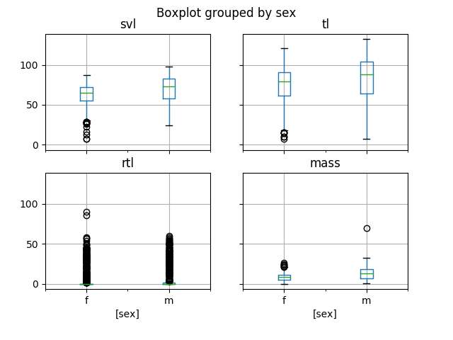

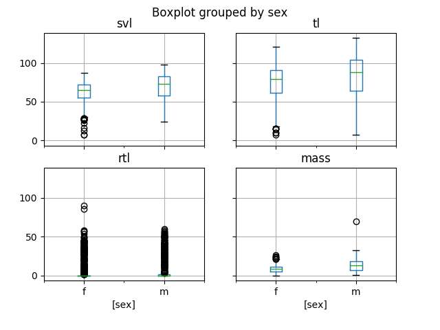

```
j    [[Axes(0.1,0.559091;0.363636x0.340909), Axes(0...
dtype: object
```

```python
df.loc[df.species=='j'].groupby('species').boxplot(column=['svl','tl','rtl','mass'],by=['sex'])
#plt.figure()
df.loc[df.species=='j'].groupby('species').boxplot(column=['svl','tl','rtl','mass'],by=['sex'])
```

Add groupby arguments that include species ageclass and sex for all summaries

```
- consider adding year
```

Types of visualizations:

- tables (autotomy, new/recap (1st sightings only)
- boxplots (svl, tl, rtl, mass)
- histograms (age class (svl), meters (location))

For inferential stats

- differences:
  - between seasons within years
  - between years (weather and fire)
  - population density (revist how to calculate this)
    - ran study until flatline
    - do we need to account for person-hours still?

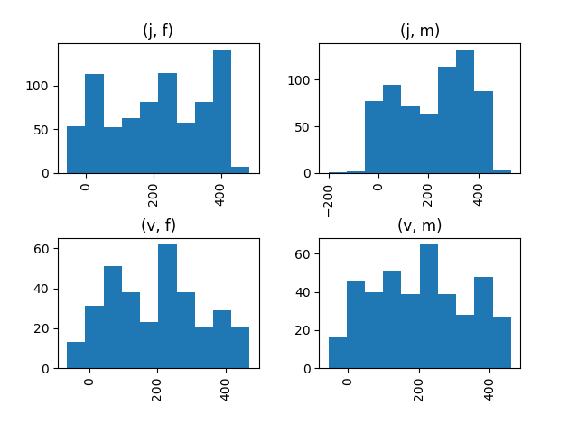

```
array([[<matplotlib.axes._subplots.AxesSubplot object at 0x000002846FB9DE10>,
        <matplotlib.axes._subplots.AxesSubplot object at 0x000002846FE9BE48>]], dtype=object)
```

```python
df.hist(column='meters',by=['species','sex'])
```

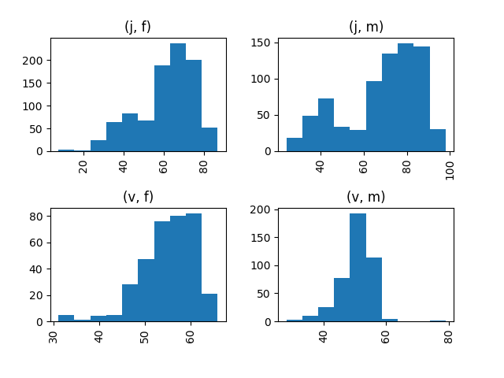

```
array([[<matplotlib.axes._subplots.AxesSubplot object at 0x0000028452AF5A20>,
        <matplotlib.axes._subplots.AxesSubplot object at 0x0000028470069B38>]], dtype=object)
```

```python
df.hist(column='svl',by=['species','sex'])
```

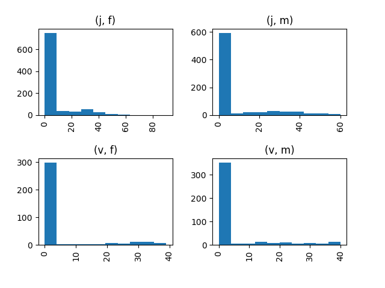

```
array([[<matplotlib.axes._subplots.AxesSubplot object at 0x00000284701CDFD0>,
        <matplotlib.axes._subplots.AxesSubplot object at 0x00000284703911D0>]], dtype=object)
```

```python
df.hist(column='rtl',by=['species','sex'])
```

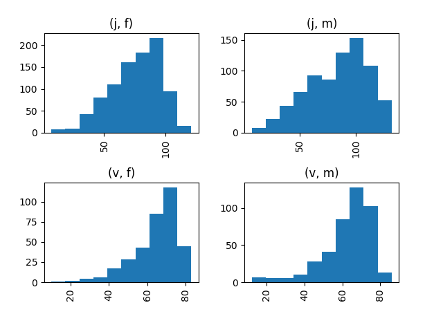

```
array([[<matplotlib.axes._subplots.AxesSubplot object at 0x00000284703F8E48>,
        <matplotlib.axes._subplots.AxesSubplot object at 0x00000284706ED898>]], dtype=object)
```

```python
df.hist(column='tl',by=['species','sex'])
```

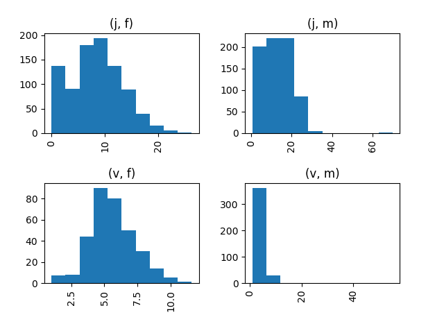

```
array([[<matplotlib.axes._subplots.AxesSubplot object at 0x0000028470562898>,
        <matplotlib.axes._subplots.AxesSubplot object at 0x00000284709BDC50>]], dtype=object)
```

```python
df.hist(column='mass',by=['species','sex'])
```